# Woman’s NBA Statistic for 2016

Angela McMahon and Mia Fitzgerald

3/27/2026

## Introduction

Our data set is a record of the Woman’s NBA player stats for 2016. It is the basic stats of each woman’s NBA player. This includes their team, position, number of games played and started in, minutes per game, and all shooting stats. They measured the number of free throws, field goals, 2 point, and 3 point attempts each player had along with all made shots and the percentages of these categories. This data set has a sample size of 174 different players. Link to data set: https://www.basketball-reference.com/wnba/years/2016_totals.html

## Data Import

To load our data set, the table was translated into a CSV and the data was copied and pasted. The data was then stored as WNBA_2016_stats. There was 2 variables which has duplicate columns, these were Games (G) and Minutes Played (MP). The duplicate columns were removed from the data. The columns for shooting percentages used the symbol which R does not accommodate. Those percentage symbols were changed into P’s. It should be noted the percentages are recorded in decimal form in the data set.

```r
library(readr)
WNBA_2016stats <- read_csv("WNBA_2016stats.csv")
WNBA_2016stats <- WNBA_2016stats%>% select(-G2, -MP2)
```

## Univariate Data

### Number of Games Started

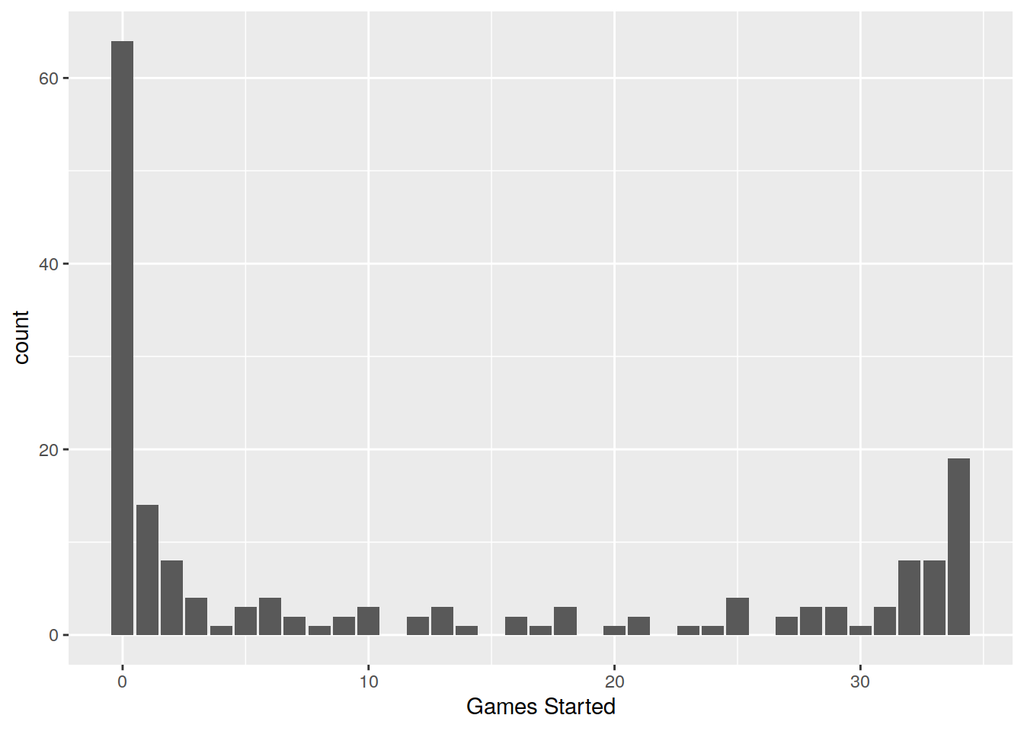

```r
WNBA_2016stats%>%
  ggplot(aes(x=GS)) +
  geom_bar()+
  labs(x="Games Started")
```

```r
WNBA_2016stats%>%
  summarize(
    Avg_Started = mean(GS),
    StDev_Started = sd(GS))%>% kable()
```

| Avg_Started | StDev_Started |
| --- | --- |
| 11.82759 | 13.86033 |

Here the category used was Games Started. This was measured as the number of games a player started in the given year (2016). On average a player starts 11.8 games in a year with a standard deviation of 13.9. It is interesting the highest count is when Games Started is zero, so many players do not start in a game. However, the second highest is over 30, indicating that players who start once will often continue to start. And those who do not will most likely not for most/all of the year.

### Player Field Goal Percentage

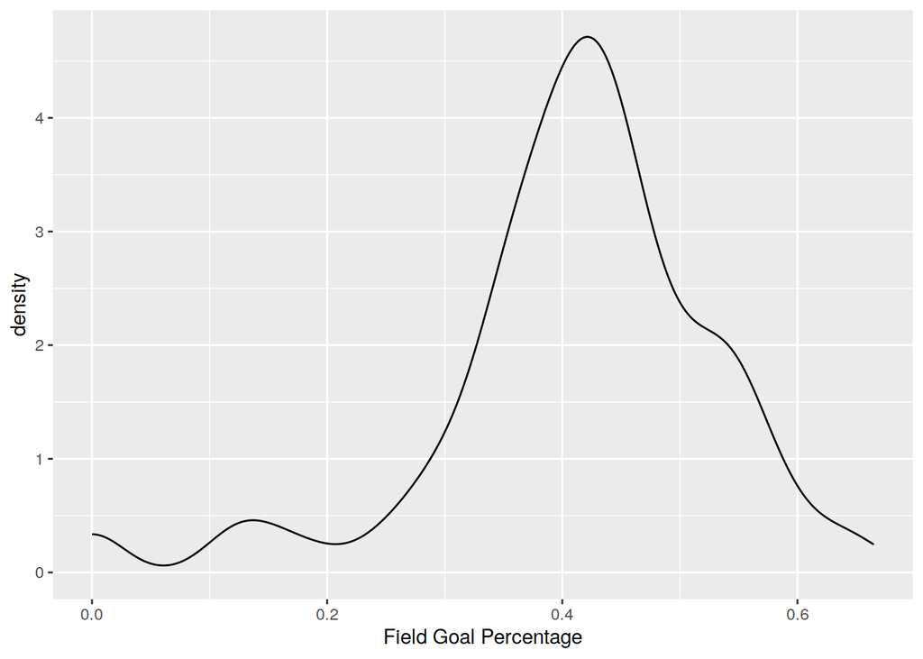

```r
WNBA_2016stats%>%
  ggplot(aes(x=FGP)) +
  geom_density()+
  labs(x="Field Goal Percentage")
```

```r
WNBA_FGP_2016 <- WNBA_2016stats %>%
  select(FGP)
summary(WNBA_FGP_2016) %>%
  kable()
```

|  | FGP |
| --- | --- |
|  | Min. :0.0000 |
|  | 1st Qu.:0.3633 |
|  | Median :0.4215 |
|  | Mean :0.4105 |
|  | 3rd Qu.:0.4783 |
|  | Max. :0.6650 |
|  | NA’s :2 |

### Number of Assists

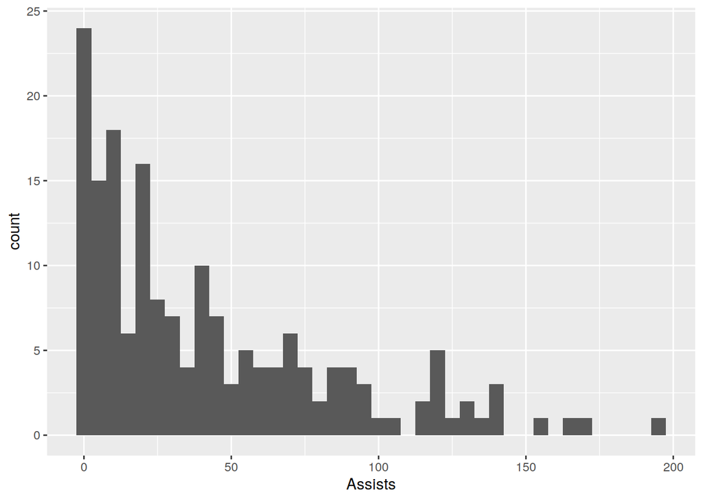

```r
WNBA_2016stats%>%
  ggplot(aes(x=AST))+
  geom_histogram(binwidth=5)+
  labs(x="Assists")
```

```r
WNBA_2016assists <- WNBA_2016stats %>%
  select(AST)
summary(WNBA_2016assists) %>%
  kable()
```

|  | AST |
| --- | --- |
|  | Min. : 0.00 |
|  | 1st Qu.: 9.00 |
|  | Median : 27.50 |
|  | Mean : 42.36 |
|  | 3rd Qu.: 66.00 |
|  | Max. :196.00 |

The last variable examined in the univariate section is player assists in a given year. The histogram depicts the data is skewed to the right. There is one outlier right below 200 assists. The average number of assists for a WNBA player in 2016 is 42. While the median is 27, supporting the histogram showing a skewed relation. The first quantile is 9 and the third quantile is 66.

## Bivariate Data

### Teams and their Average Free Throw Percentage

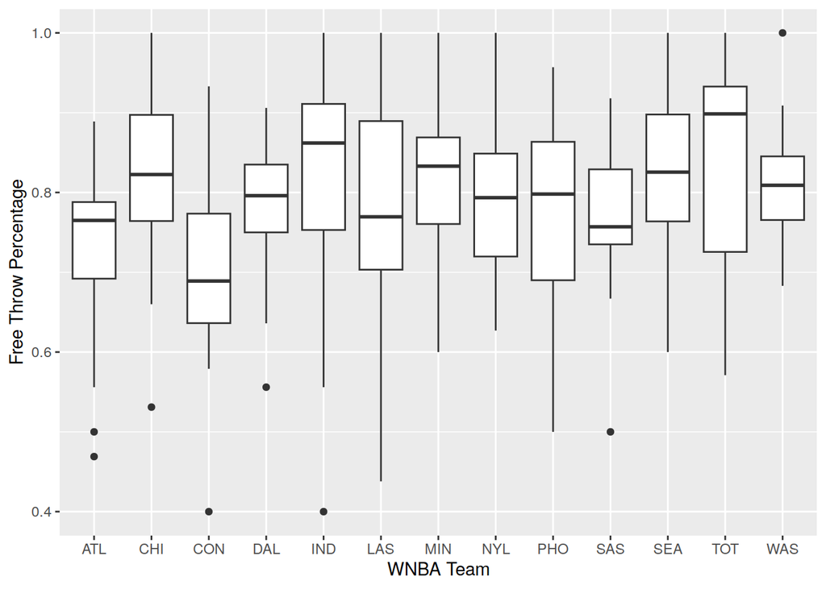

```r
WNBA_2016stats%>%
  ggplot(aes(x=Team, y=FTP))+
  geom_boxplot()+
  labs(x="WNBA Team", y="Free Throw Percentage")
```

```r
WNBA_2016stats%>%
  group_by(Team) %>%
  summarize(
    Avg_FTP = mean(FTP, na.rm=TRUE),
    StDev_FTP = sd(FTP, na.rm=TRUE)) %>%
  kable()
```

| Team | Avg_FTP | StDev_FTP |
| --- | --- | --- |
| ATL | 0.7200769 | 0.1301451 |
| CHI | 0.8134167 | 0.1281607 |
| CON | 0.7019286 | 0.1339009 |
| DAL | 0.7810769 | 0.1003938 |
| IND | 0.8086154 | 0.1731471 |
| LAS | 0.7881667 | 0.1563532 |
| MIN | 0.8132727 | 0.1109983 |
| NYL | 0.7964286 | 0.1110008 |
| PHO | 0.7548000 | 0.1535235 |
| SAS | 0.7585385 | 0.1008635 |
| SEA | 0.8340000 | 0.1170062 |
| TOT | 0.8300000 | 0.1685527 |
| WAS | 0.8168571 | 0.0771590 |

### Number of Free Throw Attmepts and Number Made

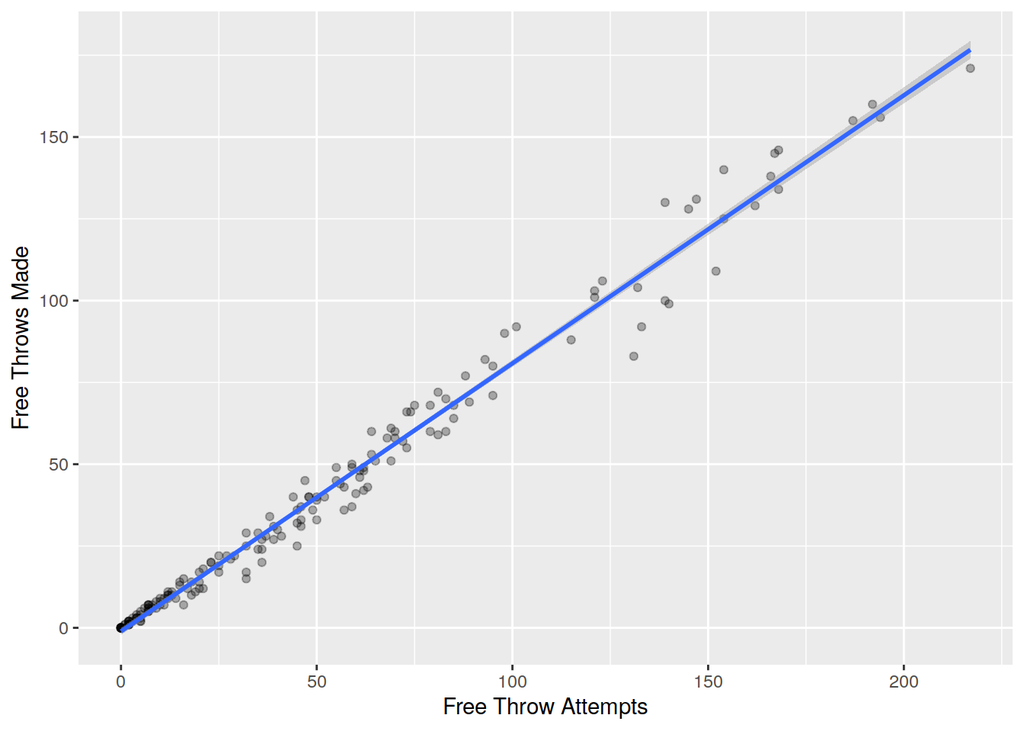

```r
WNBA_2016stats%>%
  ggplot(aes(x=FTA, y=FT))+
  geom_point(alpha=0.3)+
  geom_smooth(method="lm")+
  labs(x="Free Throw Attempts", y="Free Throws Made")
```

Player free throw attempts and player free throw shots made have a positive, relatively strong correlation. Most of the points are concentrated between 0 and 25 on both axis. There are four outliers past 175. The strong correlation highly to these players shooting skills as most points are either touching or slightly off of the line of best fit. Although it does not show direct connection to the univariate views, it supports the above conclusions.

## Trivariate Data

### Player Position and the Number and Two and Three Point Shots Made

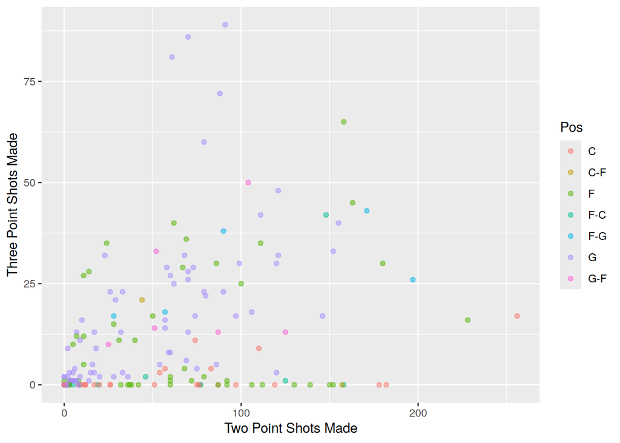

```r
WNBA_2016stats%>%
  ggplot(aes(x=TwoPt, y= ThPt, color=Pos))+
  geom_point(alpha=0.5)+
  labs(x="Two Point Shots Made", y="Three Point Shots Made")
```

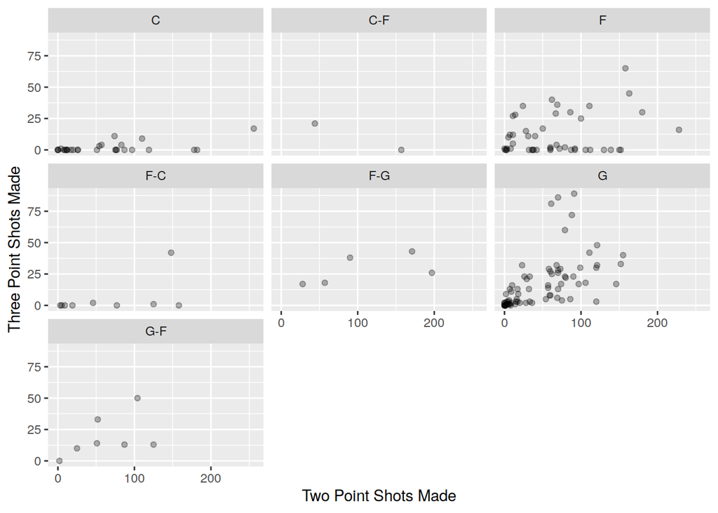

```r
WNBA_2016stats%>%
  ggplot(aes(x=TwoPt, y=ThPt))+
  geom_point(alpha=0.3)+
  labs(x="Two Point Shots Made", y="Three Point Shots Made")+
  facet_wrap(~Pos)
```

## Conclusion

The Woman’s NBA stats for 2016 give lots of insight into the strengths and weaknesses of the teams and players. The data reveals a wide range of key roles of players including the shooting activity of guards and forwards. Over 60 players do not start but are still contibuting in other areas of the game including assists and different types of shots. Shooting percentages and assist numbers highlight both individual skills and teamwork. Both the bivariate and trivariate analyses demonstrate similar ideas. Factors like team, position, and shot selection interact to shape the outcomes on the court. Overall, the data set underscore the diversity of talent in the WBNA and the multifaceted nature of basketball games offering a comprehensive view of the 2016 basketball year.